# DADA2 pipeline followed in the metagenomic analysis of soil microbiomes beneath decomposing wildebeest carcasses

## Introduction

The data pipeline used in the metagenomic analysis of soil microbiomes beneath decomposing wildebeest carcasses. This analysis follows the DADA2 Pipeline from https://benjjneb.github.io/dada2/tutorial.html

### Required packages

```r
#Packages used
library(dada2); packageVersion("dada2")
library(DECIPHER)
library(phyloseq)
library(Biostrings)
library(ggplot2)
library(vegan)
library(car)
library(DescTools)
library(ggtext)
library(tibble)
library(microbiomeMarker)
```

## Sample data

These fastq files were generated by 2x300 Illumina Miseq amplicon sequencing of the V3 - V4 region of the 16S rRNA gene from soil samples beneath and 5 meters from (control) samples.

Here you need to indicate the path where you saved the “Carcass_gene_data”

```r
# Here you need to indicate the path where you saved the "Carcass_gene_data"
# getwd()
path <- "~/redatiX/Metagenomic_Analysis_DADA2/Carcass_gene_data"
list.files(path)
```

Read in the names of the fastq files, and perform some string manipulation to get matched lists of the forward and reverse fastq files.

```r
fnFs <- sort(list.files(path, pattern="_R1_001.fastq", full.names = TRUE))
fnRs <- sort(list.files(path, pattern="_R2_001.fastq", full.names = TRUE))
# Extract sample names, assuming filenames have format:  SAMPLENAME_XXX.fastq
sample.names <- sapply(strsplit(basename(fnFs), "_"), `[`, 1)
```

## Quality profiles of the forward and reverse reads.

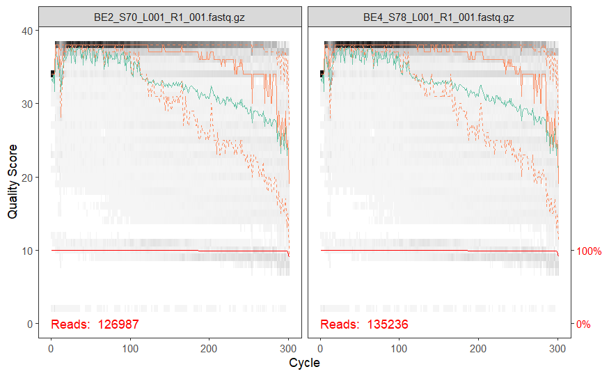

```r
plotQualityProfile(fnFs[1:2])
```

## Filter and trim

Assign the filenames for the filtered fastq.gz files.

```r
filtFs <- file.path(path, "filtered", paste0(sample.names, "_F_filt.fastq.gz"))
filtRs <- file.path(path, "filtered", paste0(sample.names, "_R_filt.fastq.gz"))
names(filtFs) <- sample.names
names(filtRs) <- sample.names
```

The standard filtering parameters used in the https://benjjneb.github.io/dada2/tutorial.html pipeline is: (fnFs, filtFs, fnRs, filtRs, truncLen=c(240,160),maxN=0, maxEE=c(2,2), truncQ=2, rm.phix=TRUE,compress=TRUE, multithread=TRUE). The error rates of the forward and reverse reads create an error model for the DADA2 algorithm. I increased the trunk length (280,210) based on the read quality observed in the plots. The left was trimmed by 25 base pairs, the right by 10, and the maxEE=c(3,4) provided better results. Other combinations were also tested.

```r
out <- filterAndTrim(fwd=fnFs, filt=filtFs, rev=fnRs, filt.rev=filtRs
                     ,truncLen=c(280,210)# (270,205)
                     ,truncQ=2
                     ,maxN=0
                     ,trimLeft = 25
                     ,trimRight = 10
                     ,maxEE=c(3,4)#(2,3)
                     ,rm.phix=TRUE
                     ,compress=TRUE
                     ,multithread=F#On Windows set multithread=FALSE
                     )
head(out)
errF <- learnErrors(filtFs, multithread=F)
errR <- learnErrors(filtRs, multithread=F)
```

## Plotting the errors.

```r
plotErrors(errF, nominalQ=FALSE)
plotErrors(errR, nominalQ=FALSE)
```

[output not shown]

De-replicate Reads to speed up computation

```r
derepFs <- derepFastq(filtFs,verbose = TRUE)
derepRs <- derepFastq(filtRs,verbose = TRUE)
names(derepFs) <- sample.names
names(derepRs) <- sample.names
```

## Sample Inference

Apply the core sample inference algorithm to the filtered and trimmed sequence data. Removed all sequencing errors to reveal the members of the sequenced community. Returns the inferred composition of the sample.

```r
dadaFs <- dada(filtFs, err=errF, multithread=F)
dadaRs <- dada(filtRs, err=errR, multithread=F)
```

Inspecting the returned dada-class object:

```r
dadaFs[[1]]
dadaRs[[1]]
```

## Merge de-noised paired end reads

The reads were only merged if the overlap by more than 12 base pairs with zero mismatches.

```r
mergers <- mergePairs(dadaFs, filtFs, dadaRs, filtRs
                      ,verbose=TRUE
                      ,minOverlap = 12
                      ,maxMismatch = 0)

head(mergers[[1]])
```

Tabulate De-noised and Merged Reads Organize ribosomal sequence variances (RSV’s) into a sequence table (analogous to and OTU table) View the length of RSV’s

```r
seqtab <- makeSequenceTable(mergers)
dim(seqtab)
table(nchar(getSequences(seqtab)))
```

## Chimera Checking and Removal

Performed a de nova chimera sequence detection and removal

```r
seqtab.nochim <- removeBimeraDenovo(seqtab, method="consensus",
                                    multithread=F, verbose=TRUE)
```

What fraction of the reads can be considered not chimeric? (1 - the score) If you have many chimeras you need to trimLeft

```r
sum(seqtab.nochim)/sum(seqtab)
```

## Assigning the taxa

This chunk may take some time Download the silva_nr_v132_train_set.fa.gz file, and place it in the directory with the fastq files. https://zenodo.org/records/1172783

```r
 taxa <- assignTaxonomy(seqtab.nochim,
                        "~/redatiX/Metagenomic_Analysis_DADA2/Carcass_gene_data/silva_nr_v132_train_set.fa.gz"
                        ,tryRC=TRUE
                        ,minBoot=80
                        ,multithread=F)
```

```r
taxa.print <- taxa # Removing sequence rownames for display only
rownames(taxa.print) <- NULL
 head(taxa.print)
 taxa.print <- taxa
```

## Handoff to phyloseq

```r
theme_set(theme_classic())
```

#Construct a simple sample data.frame from the information encoded in the filenames. Usually this step would instead involve reading the sample data in from a file.

```r
samples.out <- rownames(seqtab.nochim)
subject <- sapply(strsplit(samples.out, "D"), `[`, 1)
treatment <- substr(subject,1,1)
month <- substr(subject,2,2)
site <- substr(subject,3,3)
samdf <- data.frame(Subject=subject, Treatment=treatment, Month=month, Site=site)

samdf[samdf =="O"] <- "1"
samdf[samdf =="S"] <- "6"
samdf[samdf =="T"] <- "12"
samdf[samdf =="E"] <- "18"
samdf[samdf =="C"] <- "Control"
samdf[samdf =="B"] <- "Beneath"
head(samdf)
```

View(samdf)

```r
colnames(samdf) <- c("Subject", "Group", "Month","Site" )
samdf$Month <- factor(samdf$Month,
                      levels = c("1", "6", "12", "18"),order = T)
samdf$Group <- factor(samdf$Group)
rownames(samdf) <- samples.out
```

```r
ps1 <- phyloseq(otu_table(seqtab.nochim, taxa_are_rows=FALSE),
              tax_table(taxa),sample_data(samdf)
#              ,phy_tree(fitGTR$tree)
              )
#str(phy_tree)
dna <- Biostrings::DNAStringSet(taxa_names(ps1))
names(dna) <- taxa_names(ps1)
ps1 <- merge_phyloseq(ps1, dna)
taxa_names(ps1) <- paste0("ASV", seq(ntaxa(ps1)))
ps1
total=median(sample_sums(ps1))
```